# Risk Factor Analysis

## Outcome Variable

**Outcome Variable:** sstunted

## Predictor Variables

**Intervention Variable:** parity

**Adjustment Set:**

- arm
- W_mage
- meducyrs
- feducyrs
- hhwealth_quart
- W_mhtcm
- vagbrth
- W_nrooms
- impsan
- delta_W_mage
- delta_meducyrs
- delta_feducyrs
- delta_hhwealth_quart
- delta_W_mhtcm
- delta_vagbrth
- delta_W_nrooms
- delta_impsan

## Stratifying Variables

The analysis was stratified on these variable(s):

- agecat
- studyid
- country

## Data Summary

| agecat | studyid | country | parity | sstunted | n_cell | n |
| --- | --- | --- | --- | --- | --- | --- |
| Birth | ki1000304b-SAS-CompFeed | INDIA | 1 | 0 | 44 | 187 |
| Birth | ki1000304b-SAS-CompFeed | INDIA | 1 | 1 | 3 | 187 |
| Birth | ki1000304b-SAS-CompFeed | INDIA | 2 | 0 | 47 | 187 |
| Birth | ki1000304b-SAS-CompFeed | INDIA | 2 | 1 | 6 | 187 |
| Birth | ki1000304b-SAS-CompFeed | INDIA | 3+ | 0 | 85 | 187 |
| Birth | ki1000304b-SAS-CompFeed | INDIA | 3+ | 1 | 2 | 187 |
| Birth | ki1101329-Keneba | GAMBIA | 1 | 0 | 153 | 1407 |
| Birth | ki1101329-Keneba | GAMBIA | 1 | 1 | 3 | 1407 |
| Birth | ki1101329-Keneba | GAMBIA | 2 | 0 | 144 | 1407 |
| Birth | ki1101329-Keneba | GAMBIA | 2 | 1 | 2 | 1407 |
| Birth | ki1101329-Keneba | GAMBIA | 3+ | 0 | 1084 | 1407 |
| Birth | ki1101329-Keneba | GAMBIA | 3+ | 1 | 21 | 1407 |
| Birth | ki1126311-ZVITAMBO | ZIMBABWE | 1 | 0 | 5777 | 13829 |
| Birth | ki1126311-ZVITAMBO | ZIMBABWE | 1 | 1 | 195 | 13829 |
| Birth | ki1126311-ZVITAMBO | ZIMBABWE | 2 | 0 | 4022 | 13829 |
| Birth | ki1126311-ZVITAMBO | ZIMBABWE | 2 | 1 | 103 | 13829 |
| Birth | ki1126311-ZVITAMBO | ZIMBABWE | 3+ | 0 | 3589 | 13829 |
| Birth | ki1126311-ZVITAMBO | ZIMBABWE | 3+ | 1 | 143 | 13829 |
| Birth | ki1135781-COHORTS | GUATEMALA | 1 | 0 | 109 | 852 |
| Birth | ki1135781-COHORTS | GUATEMALA | 1 | 1 | 3 | 852 |
| Birth | ki1135781-COHORTS | GUATEMALA | 2 | 0 | 134 | 852 |
| Birth | ki1135781-COHORTS | GUATEMALA | 2 | 1 | 3 | 852 |
| Birth | ki1135781-COHORTS | GUATEMALA | 3+ | 0 | 598 | 852 |
| Birth | ki1135781-COHORTS | GUATEMALA | 3+ | 1 | 5 | 852 |
| Birth | ki1135781-COHORTS | INDIA | 1 | 0 | 674 | 4122 |
| Birth | ki1135781-COHORTS | INDIA | 1 | 1 | 22 | 4122 |
| Birth | ki1135781-COHORTS | INDIA | 2 | 0 | 1016 | 4122 |
| Birth | ki1135781-COHORTS | INDIA | 2 | 1 | 21 | 4122 |
| Birth | ki1135781-COHORTS | INDIA | 3+ | 0 | 2319 | 4122 |
| Birth | ki1135781-COHORTS | INDIA | 3+ | 1 | 70 | 4122 |

[output cut: 132 more lines]

The following strata were considered:

- agecat: 24 months, studyid: ki1017093b-PROVIDE, country: BANGLADESH
- agecat: 24 months, studyid: ki1066203-TanzaniaChild2, country: TANZANIA, UNITED REPUBLIC OF
- agecat: 24 months, studyid: ki1101329-Keneba, country: GAMBIA
- agecat: 24 months, studyid: ki1113344-GMS-Nepal, country: NEPAL
- agecat: 24 months, studyid: ki1126311-ZVITAMBO, country: ZIMBABWE
- agecat: 24 months, studyid: ki1135781-COHORTS, country: GUATEMALA
- agecat: 24 months, studyid: ki1135781-COHORTS, country: INDIA
- agecat: 24 months, studyid: ki1135781-COHORTS, country: PHILIPPINES
- agecat: 24 months, studyid: kiGH5241-JiVitA-3, country: BANGLADESH
- agecat: 6 months, studyid: ki1000304b-SAS-CompFeed, country: INDIA
- agecat: 6 months, studyid: ki1000304b-SAS-FoodSuppl, country: INDIA
- agecat: 6 months, studyid: ki1017093b-PROVIDE, country: BANGLADESH
- agecat: 6 months, studyid: ki1066203-TanzaniaChild2, country: TANZANIA, UNITED REPUBLIC OF
- agecat: 6 months, studyid: ki1101329-Keneba, country: GAMBIA
- agecat: 6 months, studyid: ki1113344-GMS-Nepal, country: NEPAL
- agecat: 6 months, studyid: ki1126311-ZVITAMBO, country: ZIMBABWE
- agecat: 6 months, studyid: ki1135781-COHORTS, country: GUATEMALA
- agecat: 6 months, studyid: ki1135781-COHORTS, country: INDIA
- agecat: 6 months, studyid: ki1135781-COHORTS, country: PHILIPPINES
- agecat: 6 months, studyid: kiGH5241-JiVitA-3, country: BANGLADESH
- agecat: Birth, studyid: ki1000304b-SAS-CompFeed, country: INDIA
- agecat: Birth, studyid: ki1101329-Keneba, country: GAMBIA
- agecat: Birth, studyid: ki1126311-ZVITAMBO, country: ZIMBABWE
- agecat: Birth, studyid: ki1135781-COHORTS, country: GUATEMALA
- agecat: Birth, studyid: ki1135781-COHORTS, country: INDIA
- agecat: Birth, studyid: ki1135781-COHORTS, country: PHILIPPINES
- agecat: Birth, studyid: kiGH5241-JiVitA-3, country: BANGLADESH

### Dropped Strata

Some strata were dropped due to rare outcomes:

- agecat: Birth, studyid: ki1000304b-SAS-CompFeed, country: INDIA
- agecat: Birth, studyid: ki1101329-Keneba, country: GAMBIA
- agecat: Birth, studyid: ki1135781-COHORTS, country: GUATEMALA
- agecat: 6 months, studyid: ki1017093b-PROVIDE, country: BANGLADESH
- agecat: 6 months, studyid: ki1066203-TanzaniaChild2, country: TANZANIA, UNITED REPUBLIC OF
- agecat: 6 months, studyid: ki1101329-Keneba, country: GAMBIA
- agecat: 24 months, studyid: ki1066203-TanzaniaChild2, country: TANZANIA, UNITED REPUBLIC OF
- agecat: 24 months, studyid: ki1101329-Keneba, country: GAMBIA

## Methods Detail

We’re interested in the causal parameters $E[Y_a]$ for all values of $a \in \mathcal{A}$. These parameters represent the mean outcome if, possibly contrary to fact, we intervened to set all units to have $A=a$. Under the randomization and positivity assumptions, these are identified by the statistical parameters $\psi_a=E_W[E_{Y|A,W}(Y|A=a,W)]$. In addition, we’re interested in the mean of $Y$, $E[Y]$ under no intervention (the observed mean). We will estimate these parameters by using SuperLearner to fit the relevant likelihood factors – $E_{Y|A,W}(Y|A=a,W)$ and $p(A=a|W)$, and then updating our likelihood fit using a joint TMLE.

For unadjusted analyses ($W=\{\}$), initial likelihoods were estimated using Lrnr_glm to estimate the simple $E(Y|A)$ and Lrnr_mean to estimate $p(A)$. For adjusted analyses, a small library containing Lrnr_glmnet, Lrnr_xgboost, and Lrnr_mean was used.

Having estimated these parameters, we will then use the delta method to estimate relative risks and attributable risks relative to a prespecified baseline level of $A$.

# Results Detail

## Results Plots

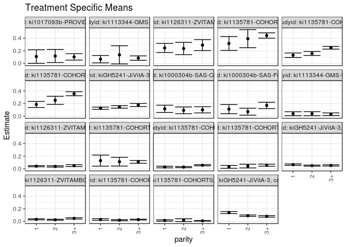

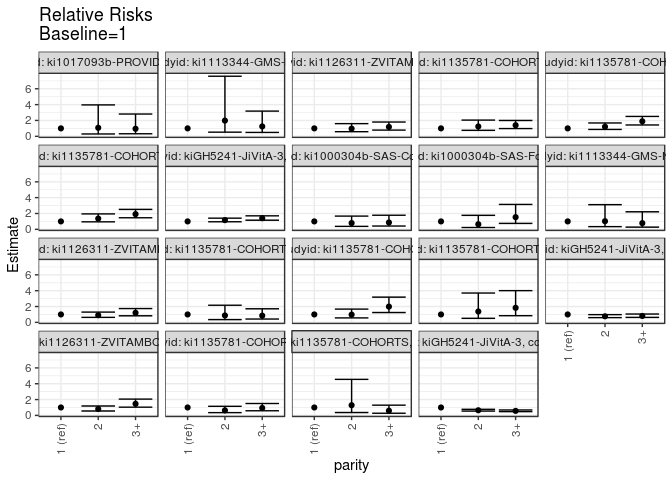

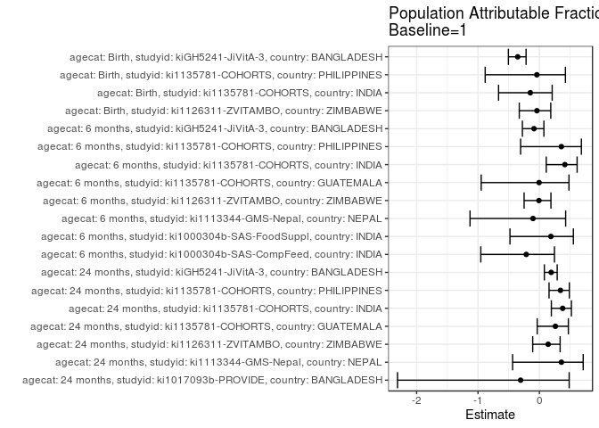

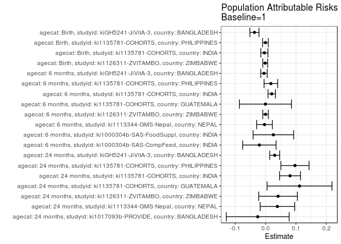

## Results Table

### Parameter: TSM

| agecat | studyid | country | intervention_level | baseline_level | estimate | ci_lower | ci_upper |
| --- | --- | --- | --- | --- | --- | --- | --- |
| Birth | ki1126311-ZVITAMBO | ZIMBABWE | 1 | NA | 0.0331645 | 0.0245340 | 0.0417949 |
| Birth | ki1126311-ZVITAMBO | ZIMBABWE | 2 | NA | 0.0269718 | 0.0195320 | 0.0344117 |
| Birth | ki1126311-ZVITAMBO | ZIMBABWE | 3+ | NA | 0.0485098 | 0.0378063 | 0.0592133 |
| Birth | ki1135781-COHORTS | INDIA | 1 | NA | 0.0314770 | 0.0184434 | 0.0445106 |
| Birth | ki1135781-COHORTS | INDIA | 2 | NA | 0.0199388 | 0.0114246 | 0.0284530 |
| Birth | ki1135781-COHORTS | INDIA | 3+ | NA | 0.0295188 | 0.0227484 | 0.0362892 |
| Birth | ki1135781-COHORTS | PHILIPPINES | 1 | NA | 0.0157055 | 0.0054458 | 0.0259653 |
| Birth | ki1135781-COHORTS | PHILIPPINES | 2 | NA | 0.0202093 | -0.0016454 | 0.0420641 |
| Birth | ki1135781-COHORTS | PHILIPPINES | 3+ | NA | 0.0093222 | 0.0053634 | 0.0132810 |
| Birth | kiGH5241-JiVitA-3 | BANGLADESH | 1 | NA | 0.1409016 | 0.1248906 | 0.1569126 |
| Birth | kiGH5241-JiVitA-3 | BANGLADESH | 2 | NA | 0.0914325 | 0.0797870 | 0.1030779 |
| Birth | kiGH5241-JiVitA-3 | BANGLADESH | 3+ | NA | 0.0805195 | 0.0683707 | 0.0926682 |
| 6 months | ki1000304b-SAS-CompFeed | INDIA | 1 | NA | 0.1163526 | 0.0589468 | 0.1737585 |
| 6 months | ki1000304b-SAS-CompFeed | INDIA | 2 | NA | 0.0922177 | 0.0385571 | 0.1458784 |
| 6 months | ki1000304b-SAS-CompFeed | INDIA | 3+ | NA | 0.1004848 | 0.0517072 | 0.1492624 |
| 6 months | ki1000304b-SAS-FoodSuppl | INDIA | 1 | NA | 0.1111111 | 0.0384223 | 0.1837999 |
| 6 months | ki1000304b-SAS-FoodSuppl | INDIA | 2 | NA | 0.0714286 | 0.0162799 | 0.1265772 |
| 6 months | ki1000304b-SAS-FoodSuppl | INDIA | 3+ | NA | 0.1705069 | 0.1204022 | 0.2206116 |
| 6 months | ki1113344-GMS-Nepal | NEPAL | 1 | NA | 0.0392157 | 0.0084312 | 0.0700001 |
| 6 months | ki1113344-GMS-Nepal | NEPAL | 2 | NA | 0.0402685 | 0.0086749 | 0.0718620 |
| 6 months | ki1113344-GMS-Nepal | NEPAL | 3+ | NA | 0.0306513 | 0.0097209 | 0.0515818 |
| 6 months | ki1126311-ZVITAMBO | ZIMBABWE | 1 | NA | 0.0420155 | 0.0320208 | 0.0520102 |
| 6 months | ki1126311-ZVITAMBO | ZIMBABWE | 2 | NA | 0.0380096 | 0.0277323 | 0.0482868 |
| 6 months | ki1126311-ZVITAMBO | ZIMBABWE | 3+ | NA | 0.0505213 | 0.0361974 | 0.0648452 |
| 6 months | ki1135781-COHORTS | GUATEMALA | 1 | NA | 0.1296257 | 0.0421208 | 0.2171307 |
| 6 months | ki1135781-COHORTS | GUATEMALA | 2 | NA | 0.1129840 | 0.0440032 | 0.1819647 |
| 6 months | ki1135781-COHORTS | GUATEMALA | 3+ | NA | 0.1097486 | 0.0872165 | 0.1322807 |
| 6 months | ki1135781-COHORTS | INDIA | 1 | NA | 0.0283590 | 0.0159271 | 0.0407909 |
| 6 months | ki1135781-COHORTS | INDIA | 2 | NA | 0.0276056 | 0.0187749 | 0.0364363 |
| 6 months | ki1135781-COHORTS | INDIA | 3+ | NA | 0.0564185 | 0.0466684 | 0.0661687 |
| 6 months | ki1135781-COHORTS | PHILIPPINES | 1 | NA | 0.0312953 | 0.0085897 | 0.0540009 |
| 6 months | ki1135781-COHORTS | PHILIPPINES | 2 | NA | 0.0429983 | 0.0137532 | 0.0722434 |
| 6 months | ki1135781-COHORTS | PHILIPPINES | 3+ | NA | 0.0575489 | 0.0410284 | 0.0740694 |
| 6 months | kiGH5241-JiVitA-3 | BANGLADESH | 1 | NA | 0.0659640 | 0.0543571 | 0.0775708 |
| 6 months | kiGH5241-JiVitA-3 | BANGLADESH | 2 | NA | 0.0505255 | 0.0419071 | 0.0591438 |
| 6 months | kiGH5241-JiVitA-3 | BANGLADESH | 3+ | NA | 0.0534848 | 0.0436286 | 0.0633410 |
| 24 months | ki1017093b-PROVIDE | BANGLADESH | 1 | NA | 0.1108835 | 0.0029744 | 0.2187926 |
| 24 months | ki1017093b-PROVIDE | BANGLADESH | 2 | NA | 0.1191796 | 0.0161599 | 0.2221993 |
| 24 months | ki1017093b-PROVIDE | BANGLADESH | 3+ | NA | 0.1051579 | 0.0546307 | 0.1556850 |
| 24 months | ki1113344-GMS-Nepal | NEPAL | 1 | NA | 0.0693703 | 0.0107909 | 0.1279498 |
| 24 months | ki1113344-GMS-Nepal | NEPAL | 2 | NA | 0.1375073 | -0.0062986 | 0.2813132 |
| 24 months | ki1113344-GMS-Nepal | NEPAL | 3+ | NA | 0.0862482 | 0.0511524 | 0.1213440 |
| 24 months | ki1126311-ZVITAMBO | ZIMBABWE | 1 | NA | 0.2461986 | 0.1735448 | 0.3188525 |
| 24 months | ki1126311-ZVITAMBO | ZIMBABWE | 2 | NA | 0.2374197 | 0.1397678 | 0.3350716 |
| 24 months | ki1126311-ZVITAMBO | ZIMBABWE | 3+ | NA | 0.2916570 | 0.2045550 | 0.3787589 |
| 24 months | ki1135781-COHORTS | GUATEMALA | 1 | NA | 0.3174333 | 0.2076334 | 0.4272333 |
| 24 months | ki1135781-COHORTS | GUATEMALA | 2 | NA | 0.3934891 | 0.2509133 | 0.5360649 |
| 24 months | ki1135781-COHORTS | GUATEMALA | 3+ | NA | 0.4430176 | 0.4003679 | 0.4856673 |
| 24 months | ki1135781-COHORTS | INDIA | 1 | NA | 0.1316979 | 0.0962123 | 0.1671835 |
| 24 months | ki1135781-COHORTS | INDIA | 2 | NA | 0.1591037 | 0.1284484 | 0.1897590 |
| 24 months | ki1135781-COHORTS | INDIA | 3+ | NA | 0.2493705 | 0.2281847 | 0.2705563 |
| 24 months | ki1135781-COHORTS | PHILIPPINES | 1 | NA | 0.1850239 | 0.1372440 | 0.2328038 |
| 24 months | ki1135781-COHORTS | PHILIPPINES | 2 | NA | 0.2509964 | 0.1868675 | 0.3151253 |
| 24 months | ki1135781-COHORTS | PHILIPPINES | 3+ | NA | 0.3550247 | 0.3236210 | 0.3864284 |
| 24 months | kiGH5241-JiVitA-3 | BANGLADESH | 1 | NA | 0.1258943 | 0.1085349 | 0.1432536 |
| 24 months | kiGH5241-JiVitA-3 | BANGLADESH | 2 | NA | 0.1461853 | 0.1262678 | 0.1661029 |
| 24 months | kiGH5241-JiVitA-3 | BANGLADESH | 3+ | NA | 0.1764732 | 0.1521754 | 0.2007710 |

### Parameter: E(Y)

| agecat | studyid | country | intervention_level | baseline_level | estimate | ci_lower | ci_upper |
| --- | --- | --- | --- | --- | --- | --- | --- |
| Birth | ki1126311-ZVITAMBO | ZIMBABWE | NA | NA | 0.0318895 | 0.0289609 | 0.0348181 |
| Birth | ki1135781-COHORTS | INDIA | NA | NA | 0.0274139 | 0.0224285 | 0.0323992 |
| Birth | ki1135781-COHORTS | PHILIPPINES | NA | NA | 0.0150820 | 0.0107558 | 0.0194081 |
| Birth | kiGH5241-JiVitA-3 | BANGLADESH | NA | NA | 0.1041135 | 0.0994385 | 0.1087885 |
| 6 months | ki1000304b-SAS-CompFeed | INDIA | NA | NA | 0.0958084 | 0.0774939 | 0.1141229 |
| 6 months | ki1000304b-SAS-FoodSuppl | INDIA | NA | NA | 0.1367292 | 0.1018167 | 0.1716417 |
| 6 months | ki1113344-GMS-Nepal | NEPAL | NA | NA | 0.0355240 | 0.0202206 | 0.0508273 |
| 6 months | ki1126311-ZVITAMBO | ZIMBABWE | NA | NA | 0.0417169 | 0.0374137 | 0.0460201 |
| 6 months | ki1135781-COHORTS | GUATEMALA | NA | NA | 0.1290323 | 0.1078261 | 0.1502384 |
| 6 months | ki1135781-COHORTS | INDIA | NA | NA | 0.0484735 | 0.0420469 | 0.0549002 |
| 6 months | ki1135781-COHORTS | PHILIPPINES | NA | NA | 0.0487445 | 0.0406327 | 0.0568562 |
| 6 months | kiGH5241-JiVitA-3 | BANGLADESH | NA | NA | 0.0606439 | 0.0567894 | 0.0644985 |
| 24 months | ki1017093b-PROVIDE | BANGLADESH | NA | NA | 0.0849220 | 0.0621566 | 0.1076874 |
| 24 months | ki1113344-GMS-Nepal | NEPAL | NA | NA | 0.1082164 | 0.0809323 | 0.1355005 |
| 24 months | ki1126311-ZVITAMBO | ZIMBABWE | NA | NA | 0.2872807 | 0.2457035 | 0.3288579 |
| 24 months | ki1135781-COHORTS | GUATEMALA | NA | NA | 0.4292409 | 0.3995279 | 0.4589539 |
| 24 months | ki1135781-COHORTS | INDIA | NA | NA | 0.2122377 | 0.1984570 | 0.2260183 |
| 24 months | ki1135781-COHORTS | PHILIPPINES | NA | NA | 0.2817996 | 0.2639639 | 0.2996353 |
| 24 months | kiGH5241-JiVitA-3 | BANGLADESH | NA | NA | 0.1558442 | 0.1471109 | 0.1645774 |

### Parameter: RR

| agecat | studyid | country | intervention_level | baseline_level | estimate | ci_lower | ci_upper |
| --- | --- | --- | --- | --- | --- | --- | --- |
| Birth | ki1126311-ZVITAMBO | ZIMBABWE | 1 | 1 | 1.0000000 | 1.0000000 | 1.0000000 |
| Birth | ki1126311-ZVITAMBO | ZIMBABWE | 2 | 1 | 0.8132746 | 0.5566045 | 1.1883042 |
| Birth | ki1126311-ZVITAMBO | ZIMBABWE | 3+ | 1 | 1.4627028 | 1.0398910 | 2.0574267 |
| Birth | ki1135781-COHORTS | INDIA | 1 | 1 | 1.0000000 | 1.0000000 | 1.0000000 |
| Birth | ki1135781-COHORTS | INDIA | 2 | 1 | 0.6334412 | 0.3494734 | 1.1481497 |
| Birth | ki1135781-COHORTS | INDIA | 3+ | 1 | 0.9377912 | 0.5841652 | 1.5054855 |
| Birth | ki1135781-COHORTS | PHILIPPINES | 1 | 1 | 1.0000000 | 1.0000000 | 1.0000000 |
| Birth | ki1135781-COHORTS | PHILIPPINES | 2 | 1 | 1.2867646 | 0.3636509 | 4.5531664 |
| Birth | ki1135781-COHORTS | PHILIPPINES | 3+ | 1 | 0.5935613 | 0.2721560 | 1.2945333 |
| Birth | kiGH5241-JiVitA-3 | BANGLADESH | 1 | 1 | 1.0000000 | 1.0000000 | 1.0000000 |
| Birth | kiGH5241-JiVitA-3 | BANGLADESH | 2 | 1 | 0.6489101 | 0.5475323 | 0.7690584 |
| Birth | kiGH5241-JiVitA-3 | BANGLADESH | 3+ | 1 | 0.5714588 | 0.4738005 | 0.6892461 |
| 6 months | ki1000304b-SAS-CompFeed | INDIA | 1 | 1 | 1.0000000 | 1.0000000 | 1.0000000 |
| 6 months | ki1000304b-SAS-CompFeed | INDIA | 2 | 1 | 0.7925712 | 0.3764194 | 1.6688012 |
| 6 months | ki1000304b-SAS-CompFeed | INDIA | 3+ | 1 | 0.8636230 | 0.4184301 | 1.7824834 |
| 6 months | ki1000304b-SAS-FoodSuppl | INDIA | 1 | 1 | 1.0000000 | 1.0000000 | 1.0000000 |
| 6 months | ki1000304b-SAS-FoodSuppl | INDIA | 2 | 1 | 0.6428571 | 0.2336797 | 1.7685119 |
| 6 months | ki1000304b-SAS-FoodSuppl | INDIA | 3+ | 1 | 1.5345622 | 0.7490708 | 3.1437363 |
| 6 months | ki1113344-GMS-Nepal | NEPAL | 1 | 1 | 1.0000000 | 1.0000000 | 1.0000000 |
| 6 months | ki1113344-GMS-Nepal | NEPAL | 2 | 1 | 1.0268456 | 0.3384542 | 3.1153756 |
| 6 months | ki1113344-GMS-Nepal | NEPAL | 3+ | 1 | 0.7816092 | 0.2761410 | 2.2123227 |
| 6 months | ki1126311-ZVITAMBO | ZIMBABWE | 1 | 1 | 1.0000000 | 1.0000000 | 1.0000000 |
| 6 months | ki1126311-ZVITAMBO | ZIMBABWE | 2 | 1 | 0.9046557 | 0.6311605 | 1.2966623 |
| 6 months | ki1126311-ZVITAMBO | ZIMBABWE | 3+ | 1 | 1.2024437 | 0.8305432 | 1.7408739 |
| 6 months | ki1135781-COHORTS | GUATEMALA | 1 | 1 | 1.0000000 | 1.0000000 | 1.0000000 |
| 6 months | ki1135781-COHORTS | GUATEMALA | 2 | 1 | 0.8716170 | 0.3507335 | 2.1660782 |
| 6 months | ki1135781-COHORTS | GUATEMALA | 3+ | 1 | 0.8466574 | 0.4181068 | 1.7144636 |
| 6 months | ki1135781-COHORTS | INDIA | 1 | 1 | 1.0000000 | 1.0000000 | 1.0000000 |
| 6 months | ki1135781-COHORTS | INDIA | 2 | 1 | 0.9734348 | 0.5660118 | 1.6741266 |
| 6 months | ki1135781-COHORTS | INDIA | 3+ | 1 | 1.9894409 | 1.2420376 | 3.1865983 |
| 6 months | ki1135781-COHORTS | PHILIPPINES | 1 | 1 | 1.0000000 | 1.0000000 | 1.0000000 |
| 6 months | ki1135781-COHORTS | PHILIPPINES | 2 | 1 | 1.3739523 | 0.5092800 | 3.7066934 |
| 6 months | ki1135781-COHORTS | PHILIPPINES | 3+ | 1 | 1.8388979 | 0.8439038 | 4.0070272 |
| 6 months | kiGH5241-JiVitA-3 | BANGLADESH | 1 | 1 | 1.0000000 | 1.0000000 | 1.0000000 |
| 6 months | kiGH5241-JiVitA-3 | BANGLADESH | 2 | 1 | 0.7659551 | 0.6001708 | 0.9775338 |
| 6 months | kiGH5241-JiVitA-3 | BANGLADESH | 3+ | 1 | 0.8108182 | 0.6263446 | 1.0496236 |
| 24 months | ki1017093b-PROVIDE | BANGLADESH | 1 | 1 | 1.0000000 | 1.0000000 | 1.0000000 |
| 24 months | ki1017093b-PROVIDE | BANGLADESH | 2 | 1 | 1.0748187 | 0.2915336 | 3.9626146 |
| 24 months | ki1017093b-PROVIDE | BANGLADESH | 3+ | 1 | 0.9483639 | 0.3202842 | 2.8081122 |
| 24 months | ki1113344-GMS-Nepal | NEPAL | 1 | 1 | 1.0000000 | 1.0000000 | 1.0000000 |
| 24 months | ki1113344-GMS-Nepal | NEPAL | 2 | 1 | 1.9822203 | 0.5180018 | 7.5852963 |
| 24 months | ki1113344-GMS-Nepal | NEPAL | 3+ | 1 | 1.2433004 | 0.4861502 | 3.1796676 |
| 24 months | ki1126311-ZVITAMBO | ZIMBABWE | 1 | 1 | 1.0000000 | 1.0000000 | 1.0000000 |
| 24 months | ki1126311-ZVITAMBO | ZIMBABWE | 2 | 1 | 0.9643420 | 0.5822024 | 1.5973060 |
| 24 months | ki1126311-ZVITAMBO | ZIMBABWE | 3+ | 1 | 1.1846409 | 0.7792298 | 1.8009757 |
| 24 months | ki1135781-COHORTS | GUATEMALA | 1 | 1 | 1.0000000 | 1.0000000 | 1.0000000 |
| 24 months | ki1135781-COHORTS | GUATEMALA | 2 | 1 | 1.2395960 | 0.7517852 | 2.0439327 |
| 24 months | ki1135781-COHORTS | GUATEMALA | 3+ | 1 | 1.3956241 | 0.9754587 | 1.9967700 |
| 24 months | ki1135781-COHORTS | INDIA | 1 | 1 | 1.0000000 | 1.0000000 | 1.0000000 |
| 24 months | ki1135781-COHORTS | INDIA | 2 | 1 | 1.2080956 | 0.8684591 | 1.6805571 |
| 24 months | ki1135781-COHORTS | INDIA | 3+ | 1 | 1.8935040 | 1.4288317 | 2.5092930 |
| 24 months | ki1135781-COHORTS | PHILIPPINES | 1 | 1 | 1.0000000 | 1.0000000 | 1.0000000 |
| 24 months | ki1135781-COHORTS | PHILIPPINES | 2 | 1 | 1.3565619 | 0.9447481 | 1.9478846 |
| 24 months | ki1135781-COHORTS | PHILIPPINES | 3+ | 1 | 1.9188041 | 1.4626983 | 2.5171350 |
| 24 months | kiGH5241-JiVitA-3 | BANGLADESH | 1 | 1 | 1.0000000 | 1.0000000 | 1.0000000 |
| 24 months | kiGH5241-JiVitA-3 | BANGLADESH | 2 | 1 | 1.1611754 | 0.9577543 | 1.4078020 |
| 24 months | kiGH5241-JiVitA-3 | BANGLADESH | 3+ | 1 | 1.4017573 | 1.1522358 | 1.7053137 |

### Parameter: PAR

| agecat | studyid | country | intervention_level | baseline_level | estimate | ci_lower | ci_upper |
| --- | --- | --- | --- | --- | --- | --- | --- |
| Birth | ki1126311-ZVITAMBO | ZIMBABWE | 1 | NA | -0.0012750 | -0.0093773 | 0.0068273 |
| Birth | ki1135781-COHORTS | INDIA | 1 | NA | -0.0040631 | -0.0157914 | 0.0076652 |
| Birth | ki1135781-COHORTS | PHILIPPINES | 1 | NA | -0.0006236 | -0.0099265 | 0.0086793 |
| Birth | kiGH5241-JiVitA-3 | BANGLADESH | 1 | NA | -0.0367881 | -0.0517727 | -0.0218035 |
| 6 months | ki1000304b-SAS-CompFeed | INDIA | 1 | NA | -0.0205442 | -0.0756305 | 0.0345420 |
| 6 months | ki1000304b-SAS-FoodSuppl | INDIA | 1 | NA | 0.0256181 | -0.0411856 | 0.0924218 |
| 6 months | ki1113344-GMS-Nepal | NEPAL | 1 | NA | -0.0036917 | -0.0295140 | 0.0221306 |
| 6 months | ki1126311-ZVITAMBO | ZIMBABWE | 1 | NA | -0.0002986 | -0.0093481 | 0.0087509 |
| 6 months | ki1135781-COHORTS | GUATEMALA | 1 | NA | -0.0005935 | -0.0864397 | 0.0852528 |
| 6 months | ki1135781-COHORTS | INDIA | 1 | NA | 0.0201146 | 0.0079779 | 0.0322512 |
| 6 months | ki1135781-COHORTS | PHILIPPINES | 1 | NA | 0.0174491 | -0.0050294 | 0.0399277 |
| 6 months | kiGH5241-JiVitA-3 | BANGLADESH | 1 | NA | -0.0053201 | -0.0159218 | 0.0052817 |
| 24 months | ki1017093b-PROVIDE | BANGLADESH | 1 | NA | -0.0259614 | -0.1295275 | 0.0776046 |
| 24 months | ki1113344-GMS-Nepal | NEPAL | 1 | NA | 0.0388461 | -0.0179933 | 0.0956855 |
| 24 months | ki1126311-ZVITAMBO | ZIMBABWE | 1 | NA | 0.0410821 | -0.0226951 | 0.1048592 |
| 24 months | ki1135781-COHORTS | GUATEMALA | 1 | NA | 0.1118075 | 0.0048356 | 0.2187794 |
| 24 months | ki1135781-COHORTS | INDIA | 1 | NA | 0.0805398 | 0.0459537 | 0.1151258 |
| 24 months | ki1135781-COHORTS | PHILIPPINES | 1 | NA | 0.0967757 | 0.0502738 | 0.1432775 |
| 24 months | kiGH5241-JiVitA-3 | BANGLADESH | 1 | NA | 0.0299499 | 0.0135382 | 0.0463616 |

### Parameter: PAF

| agecat | studyid | country | intervention_level | baseline_level | estimate | ci_lower | ci_upper |
| --- | --- | --- | --- | --- | --- | --- | --- |
| Birth | ki1126311-ZVITAMBO | ZIMBABWE | 1 | NA | -0.0399813 | -0.3277895 | 0.1854423 |
| Birth | ki1135781-COHORTS | INDIA | 1 | NA | -0.1482130 | -0.6653687 | 0.2083476 |
| Birth | ki1135781-COHORTS | PHILIPPINES | 1 | NA | -0.0413459 | -0.8831655 | 0.4241604 |
| Birth | kiGH5241-JiVitA-3 | BANGLADESH | 1 | NA | -0.3533463 | -0.5049215 | -0.2170376 |
| 6 months | ki1000304b-SAS-CompFeed | INDIA | 1 | NA | -0.2144306 | -0.9545500 | 0.2454316 |
| 6 months | ki1000304b-SAS-FoodSuppl | INDIA | 1 | NA | 0.1873638 | -0.4793715 | 0.5536094 |
| 6 months | ki1113344-GMS-Nepal | NEPAL | 1 | NA | -0.1039216 | -1.1301455 | 0.4279063 |
| 6 months | ki1126311-ZVITAMBO | ZIMBABWE | 1 | NA | -0.0071577 | -0.2492242 | 0.1880028 |
| 6 months | ki1135781-COHORTS | GUATEMALA | 1 | NA | -0.0045993 | -0.9481602 | 0.4819627 |
| 6 months | ki1135781-COHORTS | INDIA | 1 | NA | 0.4149594 | 0.1116830 | 0.6146955 |
| 6 months | ki1135781-COHORTS | PHILIPPINES | 1 | NA | 0.3579718 | -0.3059925 | 0.6843779 |
| 6 months | kiGH5241-JiVitA-3 | BANGLADESH | 1 | NA | -0.0877260 | -0.2768833 | 0.0734095 |
| 24 months | ki1017093b-PROVIDE | BANGLADESH | 1 | NA | -0.3057093 | -2.3119287 | 0.4852315 |
| 24 months | ki1113344-GMS-Nepal | NEPAL | 1 | NA | 0.3589668 | -0.4362126 | 0.7138839 |
| 24 months | ki1126311-ZVITAMBO | ZIMBABWE | 1 | NA | 0.1430032 | -0.1090371 | 0.3377648 |
| 24 months | ki1135781-COHORTS | GUATEMALA | 1 | NA | 0.2604774 | -0.0357096 | 0.4719623 |
| 24 months | ki1135781-COHORTS | INDIA | 1 | NA | 0.3794791 | 0.1949673 | 0.5217012 |
| 24 months | ki1135781-COHORTS | PHILIPPINES | 1 | NA | 0.3434202 | 0.1573066 | 0.4884295 |
| 24 months | kiGH5241-JiVitA-3 | BANGLADESH | 1 | NA | 0.1921784 | 0.0809708 | 0.2899294 |